# PCA

Shubham Shinde

# Outline

1. Load the data set heptathlon.csv. This data set contains the results for the 25 competitors of the 1988 Olympics women’s heptathlon in Seoul. The data table has 25 observations (each row has the results of one women) on the following 8 variables:
- hurdles: results 100m hurdles.
- highjump: results high jump.
- shot: results shot.
- run200m results 200m race.
- longjump results long jump.
- javelin results javelin.
- run800m: results 800m race.
- score total score.
- see Hand et al. (1993). It is necessary to score all seven events in the same direction, so that large values are good:

heptathlon$hurdles <- max(heptathlon$hurdles) - heptathlon$hurdles heptathlon$run200m <- max(heptathlon$run200m) - heptathlon$run200m heptathlon$run800m <- max(heptathlon$run800m) - heptathlon$run800m

Problem: Compute a PCA without variable score, which is crucial for the overall result of each competitor and determines the winner.

- Can you reduce the number of variables?
- Prepare your results with Markdown/Sweave.
- Analyse the data with response score and other variables as predictors.

```r
library(factoextra)
library(dplyr)
```

# Loading the Data

```r
heptathlon <- read.csv("heptathlon.csv")
head(heptathlon, 5)
```

```
##   hurdles highjump  shot run200m longjump javelin run800m score
## 1   12.69     1.86 15.80   22.56     7.27   45.66  128.51  7291
## 2   12.85     1.80 16.23   23.65     6.71   42.56  126.12  6897
## 3   13.20     1.83 14.20   23.10     6.68   44.54  124.20  6858
## 4   13.61     1.80 15.23   23.92     6.25   42.78  132.24  6540
## 5   13.51     1.74 14.76   23.93     6.32   47.46  127.90  6540
```

```r
heptathlon$hurdles <- max(heptathlon$hurdles) - heptathlon$hurdles
heptathlon$run200m <- max(heptathlon$run200m) - heptathlon$run200m
heptathlon$run800m <- max(heptathlon$run800m) - heptathlon$run800m

heptathlon_orig <- heptathlon

heptathlon <- heptathlon %>%
  select(-score)
```

# Principal Component Analysis

```r
pca <- prcomp(heptathlon, scale = TRUE)
pca
```

```
## Standard deviations (1, .., p=7):
## [1] 2.1119364 1.0928497 0.7218131 0.6761411 0.4952441 0.2701029 0.2213617
##
## Rotation (n x k) = (7 x 7):
##                 PC1         PC2         PC3         PC4         PC5         PC6
## hurdles  -0.4528710  0.15792058 -0.04514996  0.02653873 -0.09494792 -0.78334101
## highjump -0.3771992  0.24807386 -0.36777902  0.67999172  0.01879888  0.09939981
## shot     -0.3630725 -0.28940743  0.67618919  0.12431725  0.51165201 -0.05085983
## run200m  -0.4078950 -0.26038545  0.08359211 -0.36106580 -0.64983404  0.02495639
## longjump -0.4562318  0.05587394  0.13931653  0.11129249 -0.18429810  0.59020972
## javelin  -0.0754090 -0.84169212 -0.47156016  0.12079924  0.13510669 -0.02724076
## run800m  -0.3749594  0.22448984 -0.39585671 -0.60341130  0.50432116  0.15555520
##                  PC7
## hurdles   0.38024707
## highjump -0.43393114
## shot     -0.21762491
## run200m  -0.45338483
## longjump  0.61206388
## javelin   0.17294667
## run800m  -0.09830963
```

# PCA summaries

```r
summary(pca)
```

```
## Importance of components:
##                           PC1    PC2     PC3     PC4     PC5     PC6    PC7
## Standard deviation     2.1119 1.0928 0.72181 0.67614 0.49524 0.27010 0.2214
## Proportion of Variance 0.6372 0.1706 0.07443 0.06531 0.03504 0.01042 0.0070
## Cumulative Proportion  0.6372 0.8078 0.88223 0.94754 0.98258 0.99300 1.0000
```

```r
get_eig(pca)
```

```
##       eigenvalue variance.percent cumulative.variance.percent
## Dim.1 4.46027516       63.7182165                    63.71822
## Dim.2 1.19432056       17.0617222                    80.77994
## Dim.3 0.52101413        7.4430590                    88.22300
## Dim.4 0.45716683        6.5309546                    94.75395
## Dim.5 0.24526674        3.5038106                    98.25776
## Dim.6 0.07295558        1.0422226                    99.29999
## Dim.7 0.04900101        0.7000144                   100.00000
```

```r
colSums(get_eig(pca))
```

```
##                  eigenvalue            variance.percent
##                      7.0000                    100.0000
## cumulative.variance.percent
##                    625.0329
```

```r
str(pca)
```

```
## List of 5
##  $ sdev    : num [1:7] 2.112 1.093 0.722 0.676 0.495 ...
##  $ rotation: num [1:7, 1:7] -0.453 -0.377 -0.363 -0.408 -0.456 ...
##   ..- attr(*, "dimnames")=List of 2
##   .. ..$ : chr [1:7] "hurdles" "highjump" "shot" "run200m" ...
##   .. ..$ : chr [1:7] "PC1" "PC2" "PC3" "PC4" ...
##  $ center  : Named num [1:7] 2.58 1.78 13.12 1.96 6.15 ...
##   ..- attr(*, "names")= chr [1:7] "hurdles" "highjump" "shot" "run200m" ...
##  $ scale   : Named num [1:7] 0.7366 0.0779 1.4919 0.9696 0.4742 ...
##   ..- attr(*, "names")= chr [1:7] "hurdles" "highjump" "shot" "run200m" ...
##  $ x       : num [1:25, 1:7] -4.12 -2.88 -2.65 -1.34 -1.36 ...
##   ..- attr(*, "dimnames")=List of 2
##   .. ..$ : NULL
##   .. ..$ : chr [1:7] "PC1" "PC2" "PC3" "PC4" ...
##  - attr(*, "class")= chr "prcomp"
```

```r
pca$x
```

```
##                PC1         PC2         PC3         PC4         PC5          PC6
##  [1,] -4.121447626 -1.24240435  0.36991309  0.02300174 -0.42600624  0.339329222
##  [2,] -2.882185935 -0.52372600  0.89741472 -0.47545176  0.70306588 -0.238087298
##  [3,] -2.649633766 -0.67876243 -0.45917668 -0.67962860 -0.10552518  0.239190707
##  [4,] -1.343351210 -0.69228324  0.59527044 -0.14067052  0.45392816 -0.091805638
##  [5,] -1.359025696 -1.75316563 -0.15070126 -0.83595001  0.68719483 -0.126303968
##  [6,] -1.043847471  0.07940725 -0.67453049 -0.20557253  0.73793351  0.355789386
##  [7,] -1.100385639  0.32375304 -0.07343168 -0.48627848 -0.76299122 -0.084844490
##  [8,] -0.923173639  0.80681365  0.81241866 -0.03022915  0.09086737  0.151561253
##  [9,] -0.530250689 -0.14632191  0.16122744  0.61590242  0.56851477 -0.265359696
## [10,] -0.759819024  0.52601568  0.18316881 -0.66756426 -1.02148109 -0.396397714
## [11,] -0.556268302  1.39628179 -0.13619463  0.40503603  0.29221101  0.344582964
## [12,] -1.186453832  0.35376586 -0.08201243 -0.48123479 -0.78103608 -0.233718538
## [13,]  0.015461226 -0.80644305 -1.96745373  0.73341733 -0.02177427  0.004249913
## [14,]  0.003774223 -0.71479785 -0.32496780  1.06604134 -0.18389959 -0.272903729
```

[output cut: 37 more lines]

```r
pca$rotation
```

```
##                 PC1         PC2         PC3         PC4         PC5         PC6
## hurdles  -0.4528710  0.15792058 -0.04514996  0.02653873 -0.09494792 -0.78334101
## highjump -0.3771992  0.24807386 -0.36777902  0.67999172  0.01879888  0.09939981
## shot     -0.3630725 -0.28940743  0.67618919  0.12431725  0.51165201 -0.05085983
## run200m  -0.4078950 -0.26038545  0.08359211 -0.36106580 -0.64983404  0.02495639
## longjump -0.4562318  0.05587394  0.13931653  0.11129249 -0.18429810  0.59020972
## javelin  -0.0754090 -0.84169212 -0.47156016  0.12079924  0.13510669 -0.02724076
## run800m  -0.3749594  0.22448984 -0.39585671 -0.60341130  0.50432116  0.15555520
##                  PC7
## hurdles   0.38024707
## highjump -0.43393114
## shot     -0.21762491
## run200m  -0.45338483
## longjump  0.61206388
## javelin   0.17294667
## run800m  -0.09830963
```

# Plots

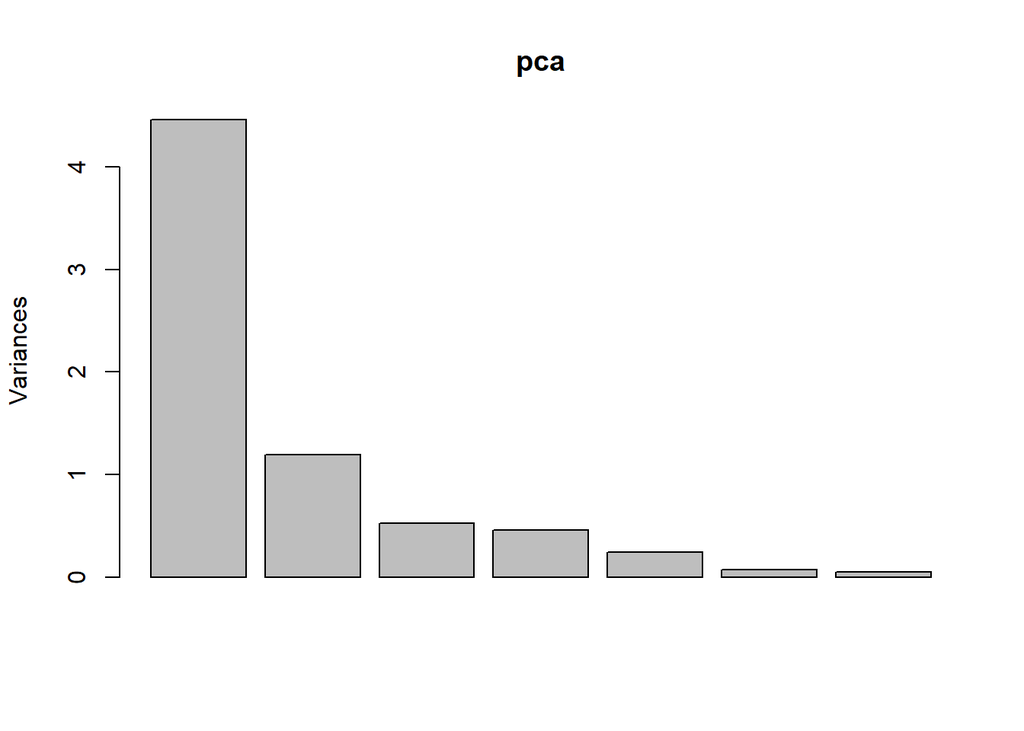

```r
plot(pca)
```

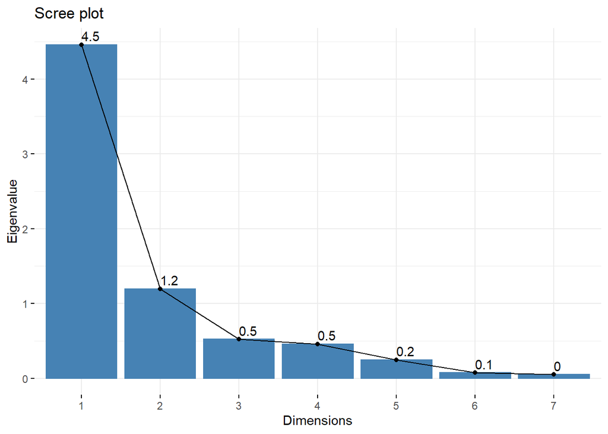

```r
fviz_eig(pca, addlabels = TRUE, choice = "eigenvalue")
```

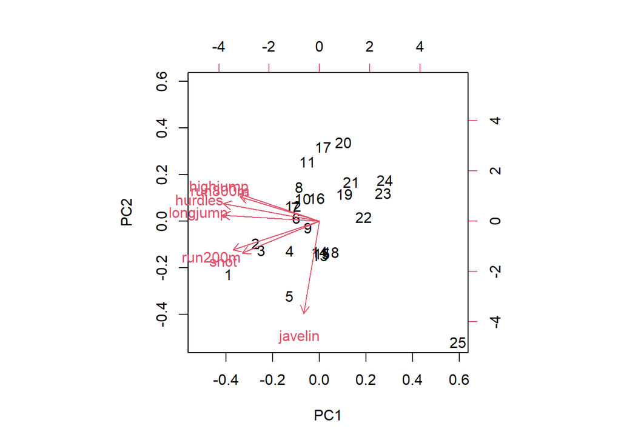

```r
biplot(pca, xpd = TRUE)
```

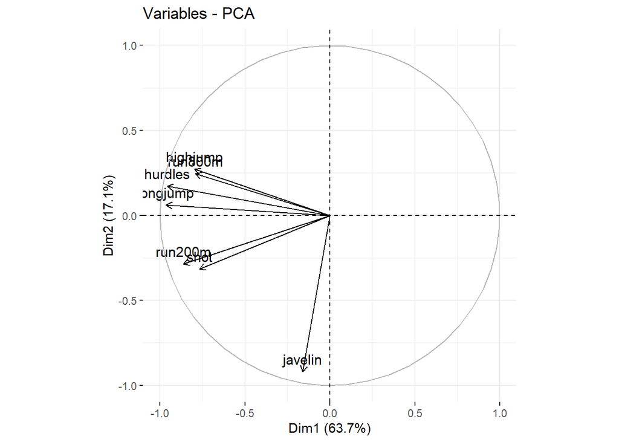

```r
fviz_pca_var(pca)
```

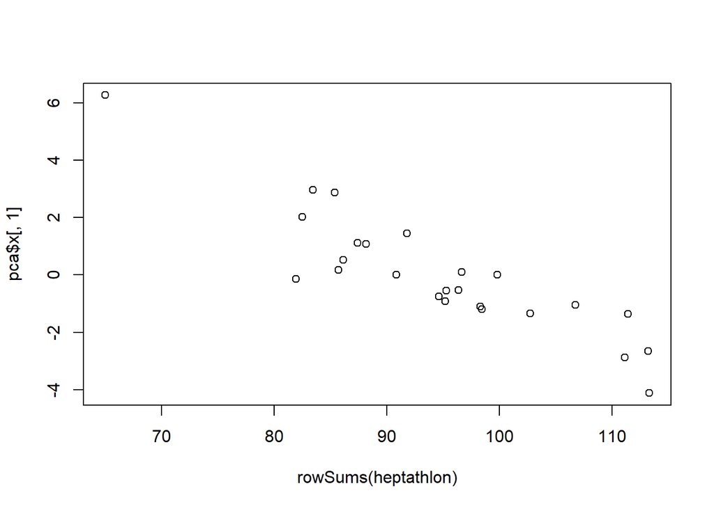

```r
plot(rowSums(heptathlon), pca$x[,1])
```